# Task6

Redkokosh Kirill

12/02/2021

```r
df <- read.csv("winequality-red.csv", header = TRUE, as.is = FALSE)
head(df)
```

```
##   fixed.acidity volatile.acidity citric.acid residual.sugar chlorides
## 1           7.4             0.70        0.00            1.9     0.076
## 2           7.8             0.88        0.00            2.6     0.098
## 3           7.8             0.76        0.04            2.3     0.092
## 4          11.2             0.28        0.56            1.9     0.075
## 5           7.4             0.70        0.00            1.9     0.076
## 6           7.4             0.66        0.00            1.8     0.075
##   free.sulfur.dioxide total.sulfur.dioxide density   pH sulphates alcohol
## 1                  11                   34  0.9978 3.51      0.56     9.4
## 2                  25                   67  0.9968 3.20      0.68     9.8
## 3                  15                   54  0.9970 3.26      0.65     9.8
## 4                  17                   60  0.9980 3.16      0.58     9.8
## 5                  11                   34  0.9978 3.51      0.56     9.4
## 6                  13                   40  0.9978 3.51      0.56     9.4
##   quality
## 1       5
## 2       5
## 3       5
## 4       6
## 5       5
## 6       5
```

### Кoрoтко о данных

Это данные о физико-химических свойствах вина, например, о кислотности, содержании диоксида серы, сульфатов и тд, а также качество вина (измеряемое баллами от 0 до 10).

1 - фиксированная кислотность

2 - летучая кислотность

3 - лимонная кислота

4 - остаточный сахар

5 - хлориды

6 - свободный диоксид серы

7 - общий диоксид серы

8 - плотность

9 - рН

10 - сульфаты

11 - алкоголь

## Первичный анализ данных

### Описательная статистика

```r
summary(df)
```

```
##  fixed.acidity   volatile.acidity  citric.acid    residual.sugar
##  Min.   : 4.60   Min.   :0.1200   Min.   :0.000   Min.   : 0.900
##  1st Qu.: 7.10   1st Qu.:0.3900   1st Qu.:0.090   1st Qu.: 1.900
##  Median : 7.90   Median :0.5200   Median :0.260   Median : 2.200
##  Mean   : 8.32   Mean   :0.5278   Mean   :0.271   Mean   : 2.539
##  3rd Qu.: 9.20   3rd Qu.:0.6400   3rd Qu.:0.420   3rd Qu.: 2.600
##  Max.   :15.90   Max.   :1.5800   Max.   :1.000   Max.   :15.500
##    chlorides       free.sulfur.dioxide total.sulfur.dioxide    density
##  Min.   :0.01200   Min.   : 1.00       Min.   :  6.00       Min.   :0.9901
##  1st Qu.:0.07000   1st Qu.: 7.00       1st Qu.: 22.00       1st Qu.:0.9956
##  Median :0.07900   Median :14.00       Median : 38.00       Median :0.9968
##  Mean   :0.08747   Mean   :15.87       Mean   : 46.47       Mean   :0.9967
##  3rd Qu.:0.09000   3rd Qu.:21.00       3rd Qu.: 62.00       3rd Qu.:0.9978
##  Max.   :0.61100   Max.   :72.00       Max.   :289.00       Max.   :1.0037
##        pH          sulphates         alcohol         quality
##  Min.   :2.740   Min.   :0.3300   Min.   : 8.40   Min.   :3.000
##  1st Qu.:3.210   1st Qu.:0.5500   1st Qu.: 9.50   1st Qu.:5.000
##  Median :3.310   Median :0.6200   Median :10.20   Median :6.000
##  Mean   :3.311   Mean   :0.6581   Mean   :10.42   Mean   :5.636
##  3rd Qu.:3.400   3rd Qu.:0.7300   3rd Qu.:11.10   3rd Qu.:6.000
##  Max.   :4.010   Max.   :2.0000   Max.   :14.90   Max.   :8.000
```

Удалим из рассмотрения free.sulfur.dioxide, так как есть total.sulfur.dioxide и удалим citric.acid, так как есть fixed.acidity.

```r
df <- df[c(-3,-6)]
names(df)[names(df) == 'fixed.acidity'] <- 'log_fixed.acidity'
names(df)[names(df) == 'residual.sugar'] <- 'log_residual.sugar'
names(df)[names(df) == 'chlorides'] <- 'log_chlorides'
names(df)[names(df) == 'total.sulfur.dioxide'] <- 'log_total.sulfur.dioxide'
names(df)[names(df) == 'sulphates'] <- 'log_sulphates'
names(df)[names(df) == 'alcohol'] <- 'log_alcohol'
```

```r
df$quality <- df$quality >= 6
```

### Виды признаков

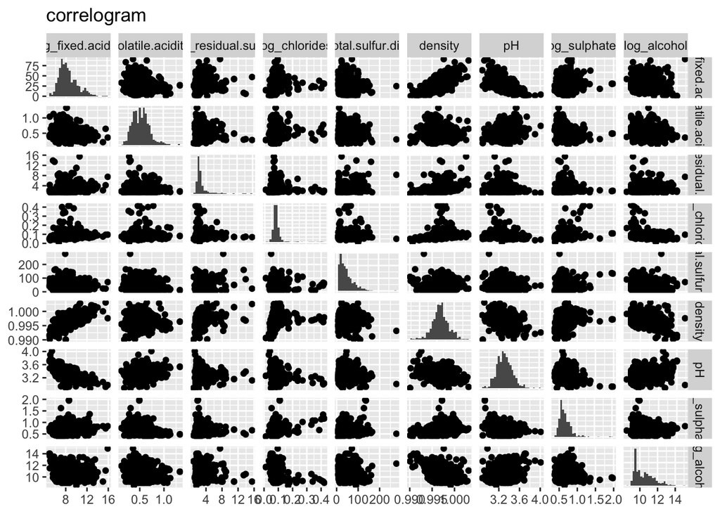

```r
library(lattice)
library(ggplot2)
library('GGally')
set.seed(1)
tr.index = sample(1:nrow(df), nrow(df)*0.5)
dfTrain = df[tr.index, ]
dfTest = df[-tr.index, ]
ggpairs(dfTrain, title="correlogram", columns=c(1:9), upper = list(continuous = "points"), diag = list(continuous = "barDiag"))
```

Прологарифмируем 1, 3, 4, 5, 8, 9.

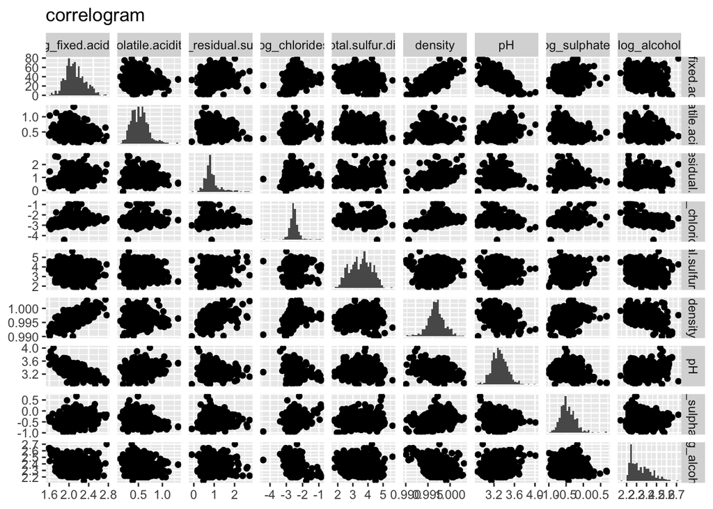

```r
dfTrain_l <- transform(dfTrain, log_fixed.acidity=log(log_fixed.acidity), log_residual.sugar=log(log_residual.sugar), log_chlorides=log(log_chlorides), log_total.sulfur.dioxide=log(log_total.sulfur.dioxide), log_sulphates=log(log_sulphates), log_alcohol=log(log_alcohol))
dfTest <- transform(dfTest, log_fixed.acidity=log(log_fixed.acidity), log_residual.sugar=log(log_residual.sugar), log_chlorides=log(log_chlorides), log_total.sulfur.dioxide=log(log_total.sulfur.dioxide), log_sulphates=log(log_sulphates), log_alcohol=log(log_alcohol))
ggpairs(dfTrain_l, title="correlogram", columns=c(1:9), upper = list(continuous = "points"), diag = list(continuous = "barDiag"))
```

Удалим единичные outliers.

А также добавим раскраску по признаку “quality”.

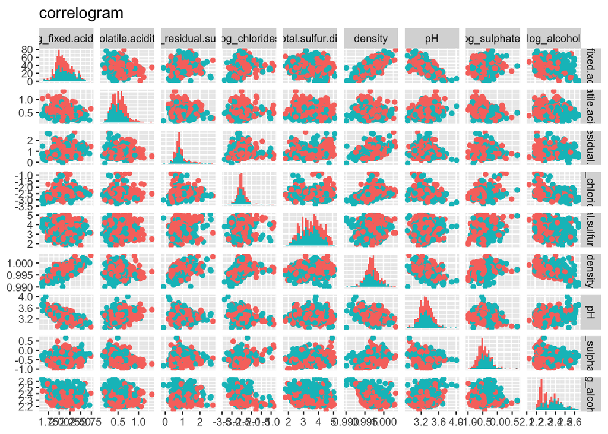

```r
dfTrain_lo <- dfTrain_l
dfTrain_lo[rownames(dfTrain_lo)[dfTrain_lo$log_chlorides < -4 | dfTrain_lo$log_total.sulfur.dioxide > 5.1 | dfTrain_lo$log_alcohol > 2.7],] <- NA
dfTrain_lo <- na.omit(dfTrain_lo)
ggpairs(dfTrain_lo, title="correlogram", columns=c(1:9), upper = list(continuous = "points"), diag = list(continuous = "barDiag"), mapping=ggplot2::aes(colour = quality))
```

Очевидного разделения на группы нет.

```r
library("factoextra")
library("FactoMineR")
res.pca <- PCA(dfTrain_lo[-10], scale.unit = TRUE, ncp = 6, graph= FALSE)
get_eigenvalue(res.pca)
```

```
##       eigenvalue variance.percent cumulative.variance.percent
## Dim.1 2.72115374       30.2350416                    30.23504
## Dim.2 1.64935071       18.3261190                    48.56116
## Dim.3 1.10613594       12.2903994                    60.85156
## Dim.4 1.05115502       11.6795003                    72.53106
## Dim.5 0.85058891        9.4509879                    81.98205
## Dim.6 0.64985886        7.2206540                    89.20270
## Dim.7 0.54379933        6.0422147                    95.24492
## Dim.8 0.37101157        4.1223508                    99.36727
## Dim.9 0.05694591        0.6327324                   100.00000
```

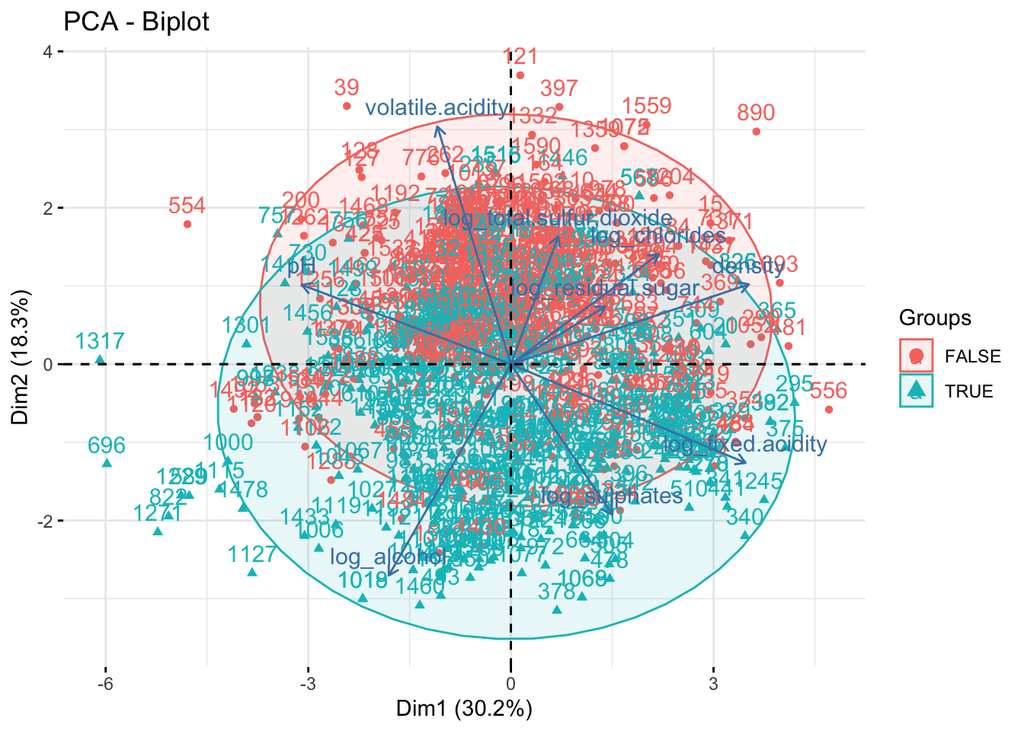

```r
fviz_pca_biplot(res.pca, habillage=dfTrain_lo$quality, addEllipses=TRUE, ellipse.level=0.95)
```

Рассматриваем первые 6 компонент, их информативность около 90%.

В плоскости первых двух главных компонент доверительный эллипс каждой группы пересекается с другой группы (Можно предположить не слишком высокое качество классификации). Ковариационные матрицы не равны (нарушается модель LDA).

Данные хорошо разделяются по второй главной компоненте.

```r
library(MASS)
fit <- lda(scale(dfTrain_lo[,1:9]), dfTrain_lo[,10]) #prior для задания весов, по умолчанию- соотношения в обучающей выборке
pred <- predict(fit, scale(dfTest[,1:9]))$class
ct <- table(pred, dfTest[,10]) #строки - настоящие классы, столбцы - предсказанные классы.
diag(prop.table(ct, 1))
```

```
##     FALSE      TRUE
## 0.6580796 0.7721180
```

```r
sum(diag(prop.table(ct)))
```

```
## [1] 0.71125
```

На test выборке лучше классифицируются хорошие вина. Общее процент правильно предсказанных индивидов– 71%.

```r
library(candisc)
candisc(lm(cbind(log_fixed.acidity, volatile.acidity, log_residual.sugar, log_chlorides, log_total.sulfur.dioxide, density, pH, log_sulphates, log_alcohol) ~ quality, data=dfTrain_lo))
```

```
##
## Canonical Discriminant Analysis for quality:
##
##   CanRsq Eigenvalue Difference Percent Cumulative
## 1 0.3104    0.45012                100        100
##
## Test of H0: The canonical correlations in the
## current row and all that follow are zero
##
##   LR test stat approx F numDF denDF   Pr(> F)
## 1       0.6896    39.21     9   784 < 2.2e-16 ***
## ---
## Signif. codes:  0 '***' 0.001 '**' 0.01 '*' 0.05 '.' 0.1 ' ' 1
```

```r
train.manova <- manova(cbind(log_fixed.acidity, volatile.acidity, log_residual.sugar, log_chlorides, log_total.sulfur.dioxide, density, pH, log_sulphates, log_alcohol) ~ quality, data=dfTrain_lo) #Смотрим на значимость дискриминации, то есть на то, отличаются ли средние по признакам между разными группами.

summary(train.manova, 'Wilks')
```

```
##            Df  Wilks approx F num Df den Df    Pr(>F)
## quality     1 0.6896    39.21      9    784 < 2.2e-16 ***
## Residuals 792
## ---
## Signif. codes:  0 '***' 0.001 '**' 0.01 '*' 0.05 '.' 0.1 ' ' 1
```

```r
summary(train.manova, 'Roy')
```

```
##            Df     Roy approx F num Df den Df    Pr(>F)
## quality     1 0.45012    39.21      9    784 < 2.2e-16 ***
## Residuals 792
## ---
## Signif. codes:  0 '***' 0.001 '**' 0.01 '*' 0.05 '.' 0.1 ' ' 1
```

p-value близко к нулю => классификация значима, но надо помнить, что нарушается модель (хотя количество индивидов в выборке позволяет говорить об ассимптотическом схождении).

Так как группы всего 2, то нельзя изобразить данные в плоскости первых двух канонических переменных.

```r
pred <- predict(fit, scale(dfTrain_lo[,1:9]))
ct <- table(pred$class, dfTrain_lo[,10])
ct
```

```
##
##         FALSE TRUE
##   FALSE   286  108
##   TRUE     91  309
```

```r
diag(prop.table(ct, 1))
```

```
##     FALSE      TRUE
## 0.7258883 0.7725000
```

```r
sum(diag(prop.table(ct)))
```

```
## [1] 0.7493703
```

На train выборке лучше классифицируются хорошие вина. Общее процент правильно предсказанных индивидов– 75% (выше чем на test, как и должно быть).

```r
fit_l <- lda(scale(dfTrain_lo[,1:9]), dfTrain_lo[,10], CV=TRUE)
ct <- table(dfTrain_lo$quality, fit_l$class)
ct
```

```
##
##         FALSE TRUE
##   FALSE   285   92
##   TRUE    111  306
```

```r
diag(prop.table(ct, 1)) #train выборка leave-one-out cross-validation
```

```
##     FALSE      TRUE
## 0.7559682 0.7338129
```

```r
sum(diag(prop.table(ct)))
```

```
## [1] 0.7443325
```

Построим ROC-кривые для проверки на train данных и train с cross-validation.

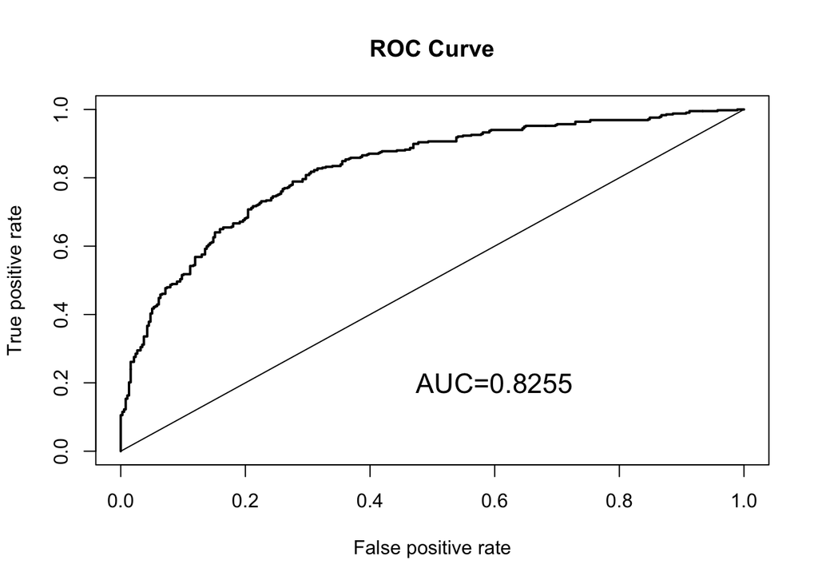

```r
library(ROCR)
pred1 <- prediction(pred$posterior[,2], dfTrain_lo$quality)
plot(performance(pred1, "tpr", "fpr"),lwd=2)
lines(c(0,1),c(0,1))
auc <- slot(performance(pred1, "auc"), "y.values")[[1]]
text(0.6, 0.2,paste("AUC=", round(auc,4), sep=""), cex=1.4)
title("ROC Curve")
```

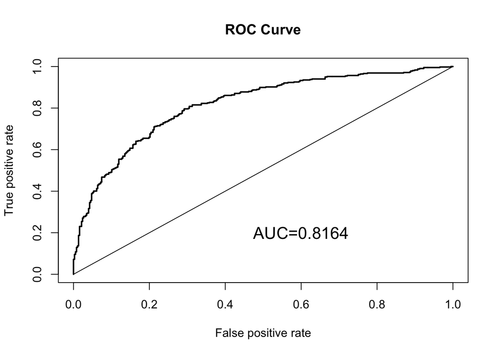

```r
pred1 <- prediction(fit_l$posterior[,2], dfTrain_lo$quality)
plot(performance(pred1, "tpr", "fpr"),lwd=2)
lines(c(0,1),c(0,1))
auc <- slot(performance(pred1, "auc"), "y.values")[[1]]
text(0.6, 0.2,paste("AUC=", round(auc,4), sep=""), cex=1.4)
title("ROC Curve")
```

Чем больше AUC, тем лучше, для train данных AUC больше (как и должно быть).

Рассмотрим ещё три модели классификации– qda, svm и randomForest.

```r
fit <- qda(scale(dfTrain_lo[,1:9]), dfTrain_lo[,10]) #prior для задания весов, по умолчанию- соотношения в обучающей выборке
pred_q <- predict(fit, scale(dfTrain_lo[,1:9])) #train выборка
ct <- table(pred_q$class, dfTrain_lo[,10]) #Столбцы - настоящие классы, строки - предсказанные классы.
ct
```

```
##
##         FALSE TRUE
##   FALSE   293  109
##   TRUE     84  308
```

```r
diag(prop.table(ct, 1))
```

```
##     FALSE      TRUE
## 0.7288557 0.7857143
```

```r
sum(diag(prop.table(ct)))
```

```
## [1] 0.756927
```

QDA при проверке на train данных показывает совсем немного лучше результаты, чем LDA на train.

```r
pred_q <- predict(fit, scale(dfTest[,1:9])) #test выборка
ct <- table(pred_q$class, dfTest[,10]) #Столбцы - настоящие классы, строки - предсказанные классы.
ct
```

```
##
##         FALSE TRUE
##   FALSE   280  136
##   TRUE     86  298
```

```r
diag(prop.table(ct, 1))
```

```
##     FALSE      TRUE
## 0.6730769 0.7760417
```

```r
sum(diag(prop.table(ct)))
```

```
## [1] 0.7225
```

QDA при проверке на test данных опять показывает совсем немного лучше результаты, чем LDA на test.

```r
fit_q <- qda(scale(dfTrain_lo[,1:9]), dfTrain_lo[,10], CV=TRUE)
ct <- table(dfTrain_lo$quality, fit_q$class)
ct
```

```
##
##         FALSE TRUE
##   FALSE   284   93
##   TRUE    118  299
```

```r
diag(prop.table(ct, 1)) #train выборка leave-one-out cross-validation
```

```
##     FALSE      TRUE
## 0.7533156 0.7170264
```

```r
sum(diag(prop.table(ct)))
```

```
## [1] 0.7342569
```

А вот при cross-validation LDA показывает результаты лучше.

```r
library(e1071)
data.svm <- svm(as.numeric(quality) ~ ., data = dfTrain_lo, scale = TRUE, type= 'C-classification')
data.svmp <- predict(data.svm, dfTest[,1:9])
ct <- table(data.svmp, as.numeric(dfTest[,10]))
ct
```

```
##
## data.svmp   0   1
##         0 298 140
##         1  68 294
```

```r
diag(prop.table(ct, 1))
```

```
##         0         1
## 0.6803653 0.8121547
```

```r
sum(diag(prop.table(ct)))
```

```
## [1] 0.74
```

Результаты лучше чем у LDA и QDA (test выборка).

```r
library(randomForest)
set.seed(1) #лес случайный, так что для воспроизводимости установим set.seed (:
rf <- randomForest(x = dfTrain_lo[-10], y = as.factor(dfTrain_lo$quality), scale = TRUE)
rfp <- predict(rf, dfTest[,1:9])
ct <- table(rfp, dfTest[,10])
ct
```

```
##
## rfp     FALSE TRUE
##   FALSE   306  111
##   TRUE     60  323
```

```r
diag(prop.table(ct, 1))
```

```
##     FALSE      TRUE
## 0.7338129 0.8433420
```

```r
sum(diag(prop.table(ct)))
```

```
## [1] 0.78625
```

Наилучшие результаты среди рассматриваемых моделей (test выборка).

Сравним ROC-кривые для моделей LDA и QDA (cross-validation проврека).

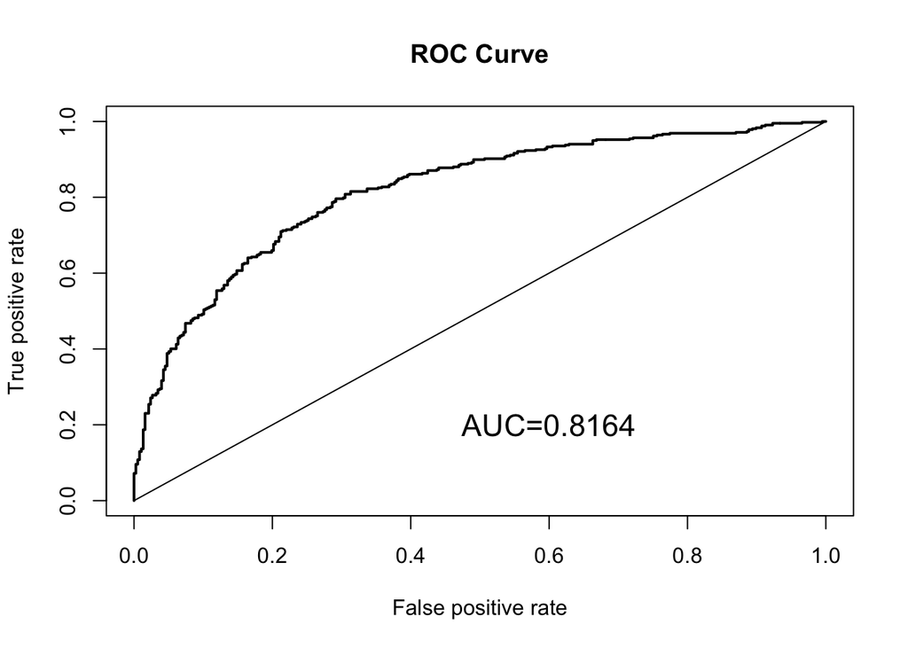

```r
pred_l <- prediction(fit_l$posterior[,2], dfTrain_lo$quality)
plot(performance(pred_l, "tpr", "fpr"),lwd=2)
lines(c(0,1),c(0,1))
auc <- slot(performance(pred_l, "auc"), "y.values")[[1]]
text(0.6, 0.2,paste("AUC=", round(auc,4), sep=""), cex=1.4)
title("ROC Curve")
```

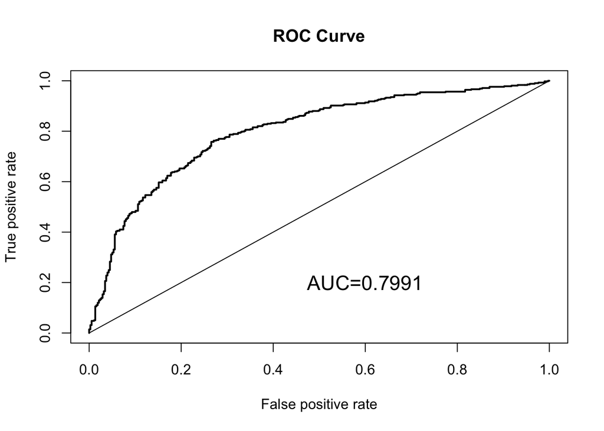

```r
pred_q <- prediction(fit_q$posterior[,2], dfTrain_lo$quality)
plot(performance(pred_q, "tpr", "fpr"),lwd=2)
lines(c(0,1),c(0,1))
auc <- slot(performance(pred_q, "auc"), "y.values")[[1]]
text(0.6, 0.2,paste("AUC=", round(auc,4), sep=""), cex=1.4)
title("ROC Curve")
```

Модель LDA показывает результаты лучше (AUC больше).

Построим модели LDA для меньшего числа признаков, для этого рассмотрим первые 6 главных компонент.

```r
pca_data <- cbind(res.pca$ind$coord, dfTrain_lo$quality)
colnames(pca_data)[7] <- "quality"
pca_test_data <- as.matrix(dfTest[,1:9])%*%as.matrix(res.pca$svd$V)
fit <- lda(scale(pca_data[,1:6]), pca_data[,7]) #prior для задания весов, по умолчанию- соотношения в обучающей выборке
fit$scaling
```

```
##               LD1
## Dim.1 -0.09472952
## Dim.2 -1.10807558
## Dim.3  0.29237697
## Dim.4  0.19804468
## Dim.5  0.25875644
## Dim.6 -0.06375221
```

Наибольшее по модулю значение соответсвует 2 главной компоненте, что поддверждает преположение, выдвинутое при рассмотрении данных в плоскости первых двух ГК.

```r
pred_pca <- predict(fit, res.pca$ind$coord) #train выборка
ct <- table(pred_pca$class, dfTrain_lo$quality) #Столбцы - настоящие классы, строки - предсказанные классы.
ct
```

```
##
##     FALSE TRUE
##   0   285  105
##   1    92  312
```

```r
diag(prop.table(ct, 1))
```

```
## [1] 0.7307692 0.7722772
```

```r
sum(diag(prop.table(ct)))
```

```
## [1] 0.7518892
```

На train выборке результаты лучше, чем у обычной LDA модели.

```r
pred <- predict(fit, scale(pca_test_data)) #test данные
ct <- table(pred$class, dfTest$quality)
ct
```

```
##
##     FALSE TRUE
##   0   254  134
##   1   112  300
```

```r
diag(prop.table(ct, 1))
```

```
## [1] 0.6546392 0.7281553
```

```r
sum(diag(prop.table(ct)))
```

```
## [1] 0.6925
```

На test выборке результаты хуже, чем у обычной LDA модели.

```r
dflo <- rbind(dfTrain_lo, dfTest)
k_f = 5 #1590/5=318
num = floor(nrow(dflo)/k_f)
tr.index = sample(1:nrow(dflo), nrow(dflo))
s = 0
for (i in 1:k_f){
  df_Train <- df[FALSE,]
  for (j in 1:k_f){
      a <- 1+num*(j-1)
      b <- num*j
    if(i!= j){
      df_Train <- rbind(df_Train, dflo[tr.index[a:b], ])
    }
    else{
      df_Test <- dflo[tr.index[a:b], ]
    }
  }
  res.pca <- PCA(df_Train[-10], scale.unit = TRUE, ncp = 6, graph= FALSE)
  pca_data <- cbind(res.pca$ind$coord, df_Train$quality)
  colnames(pca_data)[7] <- "quality"
  pca_test_data <- as.matrix(df_Test[,1:9])%*%as.matrix(res.pca$svd$V)
  fit <- lda(scale(pca_data[,1:6]), pca_data[,7])
  pred_pca <- predict(fit, scale(pca_test_data))
  ct <- table(pred_pca$class, df_Test$quality)
  s = s + sum(diag(prop.table(ct)))
}
s/k_f
```

```
## [1] 0.6836478
```

Результаты для k-fold (5 групп).